# kadai01

Rikiya Honda

2022-02-16

# データセット

```r
library(tidyverse)
path <- "~/R/project/R_tutoring/Git/R_tutoring/Data/kadai01.csv"

df_raw <- read_csv(path, locale = locale(encoding = "UTF-8"))

kadai01 <- df_raw %>%
  mutate(pref = c("Hokkaido", "Aomori", "Iwate", "Miyagi", "Akita", "Yamagata",
   "Fukushima", "Ibaraki", "Tochigi", "Gunma", "Saitama", "Chiba",
   "Tokyo", "Kanagawa", "Niigata", "Toyama", "Ishikawa", "Fukui",
   "Yamanashi", "Nagano", "Gifu", "Shizuoka", "Aichi", "Mie", "Shiga",
   "Kyoto", "Osaka", "Hyogo", "Nara", "Wakayama", "Tottori", "Shimane",
   "Okayama", "Hiroshima", "Yamaguchi", "Tokushima", "Kagawa", "Ehime",
   "Kochi", "Fukuoka", "Saga", "Nagasaki", "Kumamoto", "Oita", "Miyazaki",
   "Kagoshima", "Okinawa")
  )


# show
DT::datatable(kadai01,
              rownames = FALSE,
              extensions = 'Buttons',
              options = list(autoWidth = FALSE,
                             pageLength = 5,
                             dom = 'Bfrtip',
                             buttons = list("csv"),
                             scrollX = TRUE,
                             scrollCollapse = TRUE),
              class = 'cell-border stripe',
              caption = "source: ")
```

| pref | pop | epc |
| --- | --- | --- |
| Hokkaido | 5384 | 11070 |
| Aomori | 1309 | 2720 |
| Iwate | 1280 | 2769 |
| Miyagi | 2334 | 4819 |
| Akita | 1023 | 2177 |
| Yamagata | 1123 | 2385 |
| Fukushima | 1914 | 4017 |
| Ibaraki | 2918 | 5974 |
| Tochigi | 1975 | 4158 |
| Gunma | 1973 | 4236 |

[output cut: 37 more lines]

# データセットの呼び出しを行う

## データの読み込み（インポート）

2. データの読み込み（※ディレクトリについて） ここでは，主にCSV(Comma Separated Values)ファイルの読み込みについて説明する。 （注）ディレクトリについて ・Windowsではメニュー「ファイル」→「ディレクトリの変更」で指定できる ・Macではメニュー「その他」→「作業ディレクトリの変更」 実際に，それぞれの環境の中でデータを読み込むときは，ディレクトリの理解が不可欠になる。 例えば，JドライブのRフォルダにある”sheet1.csv”を読み込むときは次のようにする （学院のPC教室ではJドライブに資料を格納しておく）。

```r
# データを読み込む
kadai01 <- read.csv("J:/R/kadai01.csv")
```

# 1. データの提示

```r
# show the first 6 lines of `kadai01`
knitr::kable(head(kadai01))
```

| pref | pop | epc |
| --- | --- | --- |
| Hokkaido | 5384 | 11070 |
| Aomori | 1309 | 2720 |
| Iwate | 1280 | 2769 |
| Miyagi | 2334 | 4819 |
| Akita | 1023 | 2177 |
| Yamagata | 1123 | 2385 |

# 2．基本統計量の計算

## 平均値・最大値・最小値・中央値

```r
summary(kadai01)
```

```
##      pref                pop             epc
##  Length:47          Min.   :  574   Min.   : 1360
##  Class :character   1st Qu.: 1114   1st Qu.: 2543
##  Mode  :character   Median : 1649   Median : 3556
##                     Mean   : 2704   Mean   : 5678
##                     3rd Qu.: 2728   3rd Qu.: 5838
##                     Max.   :13514   Max.   :28097
```

## 不偏分散

```r
lapply(kadai01[,2:3], var)
```

```
## $pop
## [1] 7444685
##
## $epc
## [1] 28866161
```

## 不偏標準偏差

```r
lapply(kadai01[,2:3], sd)
```

```
## $pop
## [1] 2728.495
##
## $epc
## [1] 5372.724
```

# 3．相関係数の計算

```r
cor(kadai01[,2], kadai01[,3])
```

```
##           epc
## pop 0.9974586
```

# 4. 線形モデルの生成

```r
kadai.lm <- lm(epc ~ pop, data = kadai01)
```

## 回帰直線を方程式を求める

```r
coef(kadai.lm)
```

```
## (Intercept)         pop
##  365.697315    1.964112
```

上記の結果から、今回の回帰係数は、切片が365.6973149で、傾きが1.9641119であることがわかる。これを線形の式に直すと、以下の通りになる。

$$epc = 365.6973149 + 1.9641119 \times pop$$

# 5. 散布図および回帰直線の描画

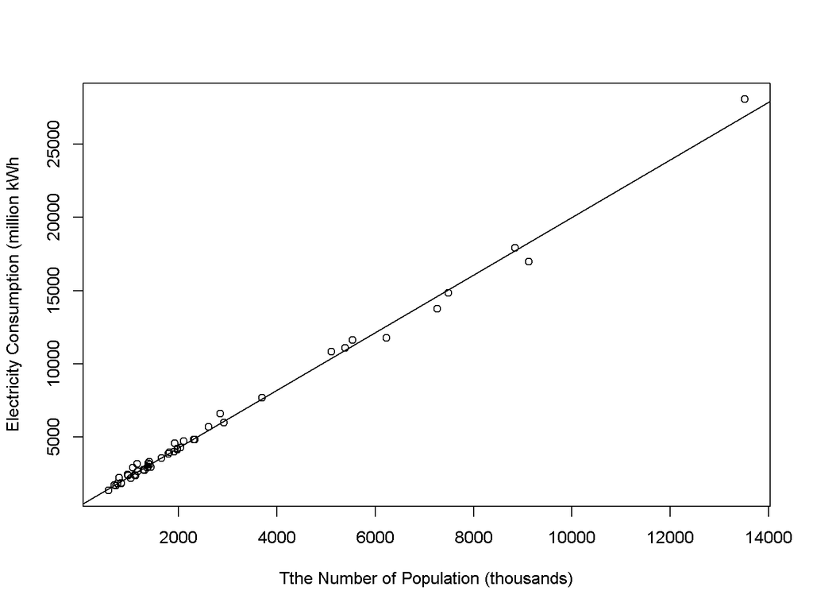

```r
plot(kadai01[,2:3],
     xlab = "Tthe Number of Population (thousands)",
     ylab = "Electricity Consumption (million kWh")
abline(kadai.lm)
```

# 6．残差（テキストp.83）の絶対値が比較的大きい都道府県に注目し、自身の考察を書きなさい。

## 残差を求める

```r
kadai01_result <- data.frame(kadai01,
                      resid = resid(kadai.lm))
```

## 並び替える

```r
head(kadai01_result[sort(kadai01_result$resid, decreasing = F, index = T)[[2]],], n = 10)

# or
kadai01_result %>%
  arrange(desc(resid)) %>%
  head(n = 10) %>%
  knitr::kable()
```

```r
kadai01_result %>%
  arrange(desc(resid)) %>%
  head(n = 10) %>%
  knitr::kable()
```

|  | pref | pop | epc | resid |
| --- | --- | --- | --- | --- |
| 13 | Tokyo | 13514 | 28097 | 1188.2946 |
| 34 | Hiroshima | 2845 | 6592 | 638.4044 |
| 17 | Ishikawa | 1154 | 3159 | 526.7176 |
| 16 | Toyama | 1067 | 2918 | 456.5953 |
| 40 | Fukuoka | 5103 | 10825 | 436.4397 |
| 33 | Okayama | 1922 | 4572 | 431.2796 |
| 28 | Hyogo | 5537 | 11626 | 385.0152 |
| 18 | Fukui | 787 | 2217 | 305.5466 |
| 20 | Nagano | 2100 | 4710 | 219.6677 |
| 26 | Kyoto | 2610 | 5703 | 210.9707 |

# 7．自己ワーク

[環境省が公表する「環境統計集（平成29年度版）」](https://www.env.go.jp/doc/toukei/h29tbl.html) のデータを用いて、グラフを１つ作成し、考察しなさい。枠内には、①使用データとそのURL、②プログラムソース、③グラフ、④考察の４点を記載しなさい。なお、データ整形は、必ずしもRを使用しなくても良い。必要があれば、データ整形に関する説明も、①使用データの部分に記載しなさい。

# ファイル提出

コード等をwordに貼って、ファイルを提出する

# APPENDIX

## summry of `kadai.lm`

```r
summary(kadai.lm)
```

```
##
## Call:
## lm(formula = epc ~ pop, data = kadai01)
##
## Residuals:
##      Min       1Q   Median       3Q      Max
## -1318.15  -129.32   -35.57   174.31  1188.29
##
## Coefficients:
##              Estimate Std. Error t value Pr(>|t|)
## (Intercept) 365.69731   79.91473   4.576 3.72e-05 ***
## pop           1.96411    0.02091  93.913  < 2e-16 ***
## ---
## Signif. codes:  0 '***' 0.001 '**' 0.01 '*' 0.05 '.' 0.1 ' ' 1
##
## Residual standard error: 387 on 45 degrees of freedom
## Multiple R-squared:  0.9949, Adjusted R-squared:  0.9948
## F-statistic:  8820 on 1 and 45 DF,  p-value: < 2.2e-16
```

## 予測値と残差

残渣(residuals)は、実際の値と予測値の差分で計算される。

以下の図だと、予測値の青の線と実際の値である赤の線の間が残差である。

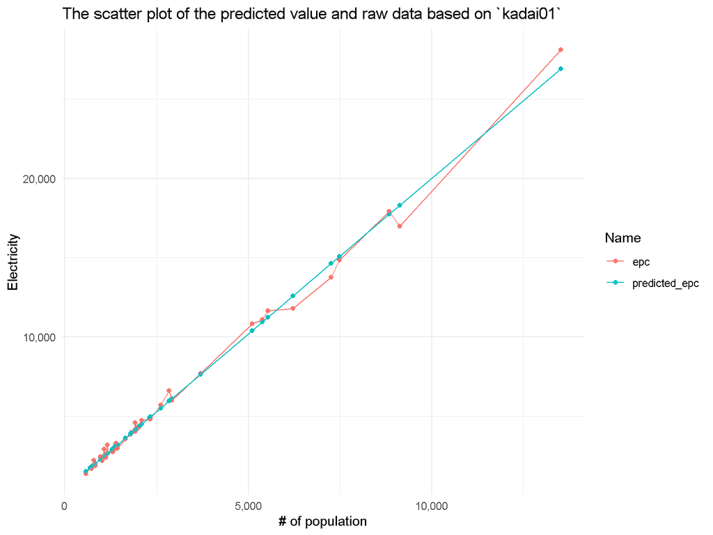

```r
# load packages
library(modelr)
library(scales)

# define the data for visualization
kadai01_plot <- kadai01 %>%
  add_predictions(kadai.lm) %>%
  add_residuals(kadai.lm) %>%
  `names<-`(value = c("pref", "pop", "epc", "predicted_epc", "residuals")) %>%
  pivot_longer(cols = c(-pref, -pop), names_to = "vars", values_to = "value")



# raw v.s. expected value
kadai01_plot %>%
  filter(vars != "residuals") %>%
  ggplot(aes(pop, value, color = vars)) +
  geom_point() +
  geom_line() +
  scale_x_continuous(labels = comma) +
  scale_y_continuous(labels = comma) +
  labs(title = "The scatter plot of the predicted value and raw data based on `kadai01`",
       x = "# of population",
       y = "Electricity",
       color = "Name") +
  theme_minimal()
```

実際の値である人口の変化によって生じる残差の値を、グラフ化したのが以下の図になる。

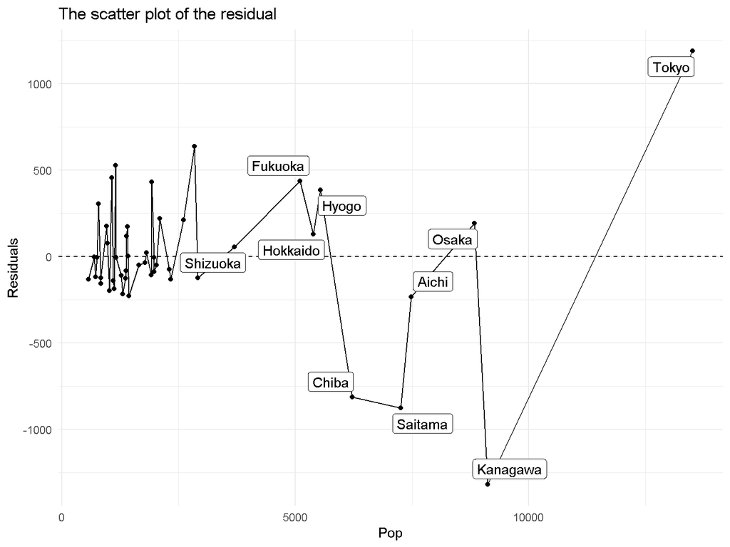

```r
# residual
kadai01_plot %>%
  filter(vars == "residuals") %>%
  ggplot(aes(pop, value)) +
  geom_hline(yintercept =  0, colour = "black", linetype = "dashed") +
  geom_point() +
  geom_line() +
  ggrepel::geom_label_repel(
    data = kadai01_plot %>% filter(vars == "residuals",
                                            pop > 3000),
    aes(label = pref),
    check_overlap = TRUE) +
  labs(title = "The scatter plot of the residual",
       x = "Pop",
       y = "Residuals") +
  theme_minimal()
```

## 日本地図

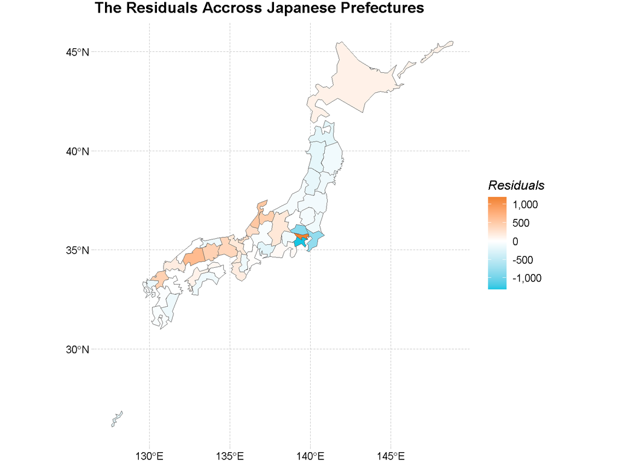

```r
pacman::p_load("NipponMap", "sf", "ggthemes")

map <- read_sf(system.file("shapes/jpn.shp", package = "NipponMap")[1],
               crs = "+proj=longlat +datum=WGS84")

map2 <-
  kadai01_plot %>%
  pivot_wider(id_cols = c(pref, pop), names_from = vars, values_from = value) %>%
  rename(name = pref) %>%
  left_join(map, by = "name") %>%
  st_sf()



ggplot(map2, aes(fill = residuals)) +
  geom_sf(size = .1) +
  labs(title = "The Residuals Accross Japanese Prefectures") +
  scale_fill_gradient2(
    name = "Residuals",
    labels = scales::number_format(big.mark = ","),
    low = "#15C6E3",
    mid = "white",
    high = "#EB7411",
    midpoint = 0) +
  theme_pander()
```